# A Brief Introduction To The 10 Simplest Machine Learning Algorithms

#### We will now use cross-validation for parameter tuning

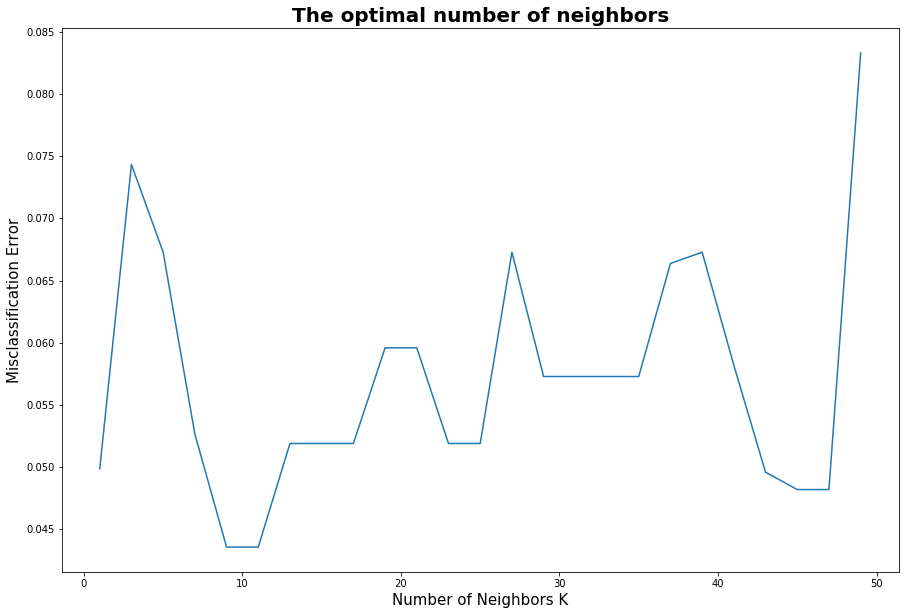

```python
# creating list of K for KNN
k_list = list(range(1,50,2))
# creating list of cv scores
cv_scores = []

# perform 10-fold cross validation
for k in k_list:
    knn = KNeighborsClassifier(n_neighbors=k)
    scores = cross_val_score(knn, X_train, y_train, cv=10, scoring='accuracy')
    cv_scores.append(scores.mean())

# changing to misclassification error
MSE = [1 - x for x in cv_scores]

plt.figure()
plt.figure(figsize=(15,10))
plt.title('The optimal number of neighbors', fontsize=20, fontweight='bold')
plt.xlabel('Number of Neighbors K', fontsize=15)
plt.ylabel('Misclassification Error', fontsize=15)

plt.plot(k_list, MSE)

plt.show()
```

#### Finding best k

```python
best_k = k_list[MSE.index(min(MSE))]
print("The optimal number of neighbors is %d." % best_k)
```

```
The optimal number of neighbors is 9.
```

## AdaBoost Classifier

### *Introduction*

Before we get started with any boosting algorithm, it is of vital importance to grasp the concept behind Ensemble Learning Technique.  
In brief, ensemble learning offers a systematic solution to combine the predictive power of multiple learners, a bit similar to how we first applied PCA on our digits dataset and then used k-means clustering to extract valuable information. The resultant is a single model which gives the aggregated output from several models. The models that form the ensemble, also known as base learners, could be either from the same learning algorithm or different learning algorithms. Bagging and boosting are two widely used ensemble learners. Though these two techniques can be used with several statistical models, the most predominant usage has been with decision trees. Decision trees, for the uninitiated, are a type of Supervised Machine Learning Model where the data is continuously split according to a certain parameter. The tree can be explained by two entities- decision nodes and leaves. The leaves are the decisions or the final outcomes. And the decision nodes are the location where the data is split.  
Now coming back to boosting algorithms, it basically refers to a family of algorithms which converts weak learners to strong learners.  
To find weak learner, we apply base learning (ML) algorithms with a different distribution iteratively. Each time base learning algorithm is applied, it generates a new weak learner. After many iterations, the boosting algorithm combines these weak rules into a single strong prediction rule. An important thing to keep in mind here is that boosting pays higher focus on examples which are mis-classiﬁed or have higher errors by preceding weak rules.

### *Basic Working of AdaBoost Algorithm*

AdaBoost, which is short for Adaptive Boosting works on a similar method as discussed above. It fits a sequence of weak learners on differently weighted training data. It starts by predicting original data set and initially assigns equal weight to each observation. If prediction is incorrect using the first learner, then it gives higher weight to observations which have been predicted incorrectly. Being an iterative process, it continues to add learners until a limit is reached in either the number of models or the accuracy. Mostly, we use decision stamps with AdaBoost. But, we can use any machine learning algorithm as base learner if it accepts weights on the training data set. We can use AdaBoost algorithms for both classification and regression problems.  
The following three are the important hyperparameters which we can tweak to improve the performance of our model

- n_estimators: It controls the number of weak learners.
- learning_rate:Controls the contribution of weak learners in the final combination. There is a trade-off between learning_rate and n_estimators.
- base_estimators: It helps to specify different ML algorithm.

In conclusion, we can surmise that AdaBoost is an easily implementable algorithm which iteratively corrects the mistakes of the weak classifier and improves accuracy by combining weak learners. We have the freedom of using many base classifiers with AdaBoost. And lastly, the greatest benefit of using AdaBoost is that it is not prone to overfitting.

### *Example Time!*

Now that we have understood this amazingly innovative method to increase accuracy, let's code it and analyse the results.

### We'll be working on the Iris flower dataset (again!) and see how much we can score on the accuracy metric.

#### Loading the required libraries

```python
from sklearn.ensemble import AdaBoostClassifier
from sklearn import datasets
from sklearn.model_selection import train_test_split
from sklearn import metrics
```

#### Loading the dataset

```python
iris = datasets.load_iris()
X = iris.data
y = iris.target
```

#### Splitting the dataset

```python
X_train, X_test, y_train, y_test = train_test_split(X, y, test_size=0.3) # 70% training and 30% test
```

#### Building the AdaBoost Model

```python
# Create adaboost classifer object
abc = AdaBoostClassifier(n_estimators=50,
                         learning_rate=1)
# Train Adaboost Classifer
model = abc.fit(X_train, y_train)

#Predict the response for test dataset
y_pred = model.predict(X_test)
```

#### Model Evaluation

```python
print("Accuracy:",metrics.accuracy_score(y_test, y_pred))
```

```
Accuracy: 0.9111111111111111
```

#### NOTE - Only one base learner has been used in this case but we can advance this model further by combining various learners and comparing their accuracies to arrive at the best subset of learners.

## Apriori Algorithm

### *Introduction*

Apriori algorithm is one of the several statistical algorithms which have been developed to implement Association Rule Mining.  
At its very core, association rule mining is a technique to identify underlying relations between different items in large datasets in order to uncover how seemingly disparate items have associations among them. ARM is mostly used to identify customer purchase patterns so that the relationship can be uilised in maximising the profit.

### *Basic Working of the Apriori Algorithm*

There are three major components of the Apriori algorithm:

- Support- This term describes how popular a particular item is. It is calculated by dividing the number of times an item is chosen by the total number of times a choice is made.  
  Suppose we need to find out the suppport for an item A, then we can do this using  
  **Support(A) = (Number of choices containing (A)) / (Total number of choices)**
- Confidence- This term estimates the likelihood that another item B will be chosen if it is given that item A has already been chosen. This concept is similar to the conditional probability which we went through under Naive Bayes Algorithm. It can be given by  
  **Confidence(A→B) = (Number of choices containing both (A and B)) / (Number of choices containing (A))**
- Lift-It refers to the increase in the ratio of the choices in favour of B when A is selected. Mathematically it can be represented as:  
  **Lift(A→B) = (Confidence (A→B))/(Support (B))**

A lift value greater than 1 means that item B is likely to be selected if item A is selected, while a value less than 1 means that item B is unlikely to be selected if item A is selected. A lift value of 1 means that (you guessed it) there is no association between A and B.

### *Example Time!*

This method needs to be implemented now on some dataset in order to further strengthen our newly acquired concepts.

### We'll be working on our custom dataset this time so that we can closely monitor how the various attributes are influencing each other.

#### Importing the libraries, creating our dataset and then calling the required functions to display the output.

```python
dataset = [['Milk', 'Onion', 'Nutmeg', 'Kidney Beans', 'Eggs', 'Yogurt'],
           ['Dill', 'Onion', 'Nutmeg', 'Kidney Beans', 'Eggs', 'Yogurt'],
           ['Milk', 'Apple', 'Kidney Beans', 'Eggs'],
           ['Milk', 'Unicorn', 'Corn', 'Kidney Beans', 'Yogurt'],
           ['Corn', 'Onion', 'Onion', 'Kidney Beans', 'Ice cream', 'Eggs']]
import pandas as pd
from mlxtend.preprocessing import TransactionEncoder

te = TransactionEncoder()
te_ary = te.fit(dataset).transform(dataset)
df = pd.DataFrame(te_ary, columns=te.columns_)
df
```

|  | Apple | Corn | Dill | Eggs | Ice cream | Kidney Beans | Milk | Nutmeg | Onion | Unicorn | Yogurt |
| --- | --- | --- | --- | --- | --- | --- | --- | --- | --- | --- | --- |
| 0 | False | False | False | True | False | True | True | True | True | False | True |
| 1 | False | False | True | True | False | True | False | True | True | False | True |
| 2 | True | False | False | True | False | True | True | False | False | False | False |
| 3 | False | True | False | False | False | True | True | False | False | True | True |
| 4 | False | True | False | True | True | True | False | False | True | False | False |

#### Returning the items and itemsets with at least 60% support

```python
from mlxtend.frequent_patterns import apriori
apriori(df, min_support=0.6, use_colnames=True)
```

|  | support | itemsets |
| --- | --- | --- |
| 0 | 0.8 | (Eggs) |
| 1 | 1.0 | (Kidney Beans) |
| 2 | 0.6 | (Milk) |
| 3 | 0.6 | (Onion) |
| 4 | 0.6 | (Yogurt) |
| 5 | 0.8 | (Kidney Beans, Eggs) |
| 6 | 0.6 | (Onion, Eggs) |
| 7 | 0.6 | (Milk, Kidney Beans) |
| 8 | 0.6 | (Onion, Kidney Beans) |
| 9 | 0.6 | (Yogurt, Kidney Beans) |
| 10 | 0.6 | (Kidney Beans, Onion, Eggs) |

## DBSCAN Algorithm

### *Introduction*

DBSCAN stands for Density Based Spatial Clustering of Applications with Noise. It is an advanced clustering algorithm which is used in cases where k-means clustering fails to achieve satisfactory results.  
We have already seen that k-means clustering is a pretty handy algorithm for most commonly occurring distributions of data. One issue with k-means clustering is that it works on the assumption that all directions are equally important for each cluster. This is usually not a major issue in many common day to day scenarios but problems arise when we are dealing with oddly shaped data ("moon" shaped distributions and the like). This problem is resolved by the DBSCAN algorithm as we shall see in the subsequent section.

### *Basic Working of the DBSCAN Algorithm*

The basis for formation of clusters in k-means was the position of the centroids of the clusters relative to a data point. In DBSCAN, there are no centroids, and clusters are formed by linking nearby points to one another. Consequently, DBSCAN does not require specifying the number of clusters but does require specifying two parameters which influence the decision of whether two nearby points should be linked into the same cluster. Another major aspect which differentiates DBSCAN from k-means is the fact that DBSCAN makes only a single pass through the data, and once a point has been assigned to a particular cluster, it never changes.  
The two parameters in DBSCAN are:

- Distance Threshold, εε (epsilon)- This is the maximum distance up till which a point can be considered a part of a particular cluster and is classified as a core sample of that cluster.
- MinPts (minimum number of points)- The minimum number of data points required in order for a group of closely spaced data points to be classified as a cluster with the encompassing data points being categorised as core samples.

It starts with any arbitrary starting point which has at least MinPts points nearby within a distance of εε. We do a breadth-first search along each of these nearby points. For a given nearby point, we check how many points it has within its radius. If it has fewer than MinPts neighbors, this point becomes a leaf, meaning we don’t continue to grow the cluster from it. If it does have at least MinPts, however, then it’s a branch, and we add all of its neighbors to the FIFO (First In First Out) queue of our breadth-first search.  
If a point has fewer than MinPts neighbors, and it isn't a leaf node of another cluster, then it’s labeled as a Noise point that doesn’t belong to any cluster.  
Once we're done with a particular cluster, we pick a new arbitrary starting point and try to grow the next cluster. This is an iterative process which continues until all the data points have been assigned.

### *Example Time!*

Let's try to cluster some oddly shaped distribution now to see how well our algorithm performs on it.

### We'll be creating a random cluster in this implementation and apply DBSCAN on it.

#### Importing the libraries and generating our cluster.

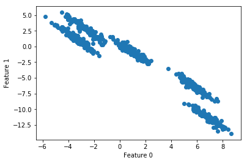

```python
import numpy as np
import matplotlib.pyplot as plt
from sklearn.datasets import make_blobs
# generate some random cluster data
X, y = make_blobs(random_state=170, n_samples=600, centers = 5)
rng = np.random.RandomState(74)
# transform the data to be stretched
transformation = rng.normal(size=(2, 2))
X = np.dot(X, transformation)
# plot
plt.scatter(X[:, 0], X[:, 1])
plt.xlabel("Feature 0")
plt.ylabel("Feature 1")
plt.show()
```

#### Applying DBSCAN on the above cluster.

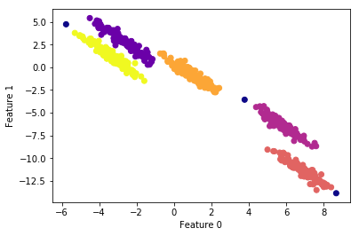

```python
from sklearn.cluster import DBSCAN
from sklearn.preprocessing import StandardScaler

scaler = StandardScaler()
X_scaled = scaler.fit_transform(X)

# cluster the data into five clusters
dbscan = DBSCAN(eps=0.123, min_samples = 2)
clusters = dbscan.fit_predict(X_scaled)

# plot the cluster assignments
plt.scatter(X[:, 0], X[:, 1], c=clusters, cmap="plasma")
plt.xlabel("Feature 0")
plt.ylabel("Feature 1")
```

#### Evaluating our model

```python
from sklearn.metrics.cluster import adjusted_rand_score

print("ARI =", adjusted_rand_score(y, clusters))
```

```
ARI = 0.9936844336049284
```

As we can clearly see, we have achieved a very high accuracy on an oddly shaped data which reinforces our belief that DBSCAN performs exceptionally well due to its novel approach to clustering. This would not have been possible with a KNN which would have marked the violet and yellow shades as similar due to its simplistic logical model

## Multilayer Perceptron

### *Introduction*

Now that we've breezed through some basic machine learning algorithms, it's time to step things up a notch. In this section, we'll be looking at Multilayer Perceptrons, the simplest neural network architecture of all.  
A multilayer perceptron (MLP) is a class of feedforward artificial neural network. It consists of a minimum of three layers of nodes: an input layer, a hidden layer and an output layer. Except for the input nodes, each node is a neuron that uses a nonlinear activation function. MLP utilizes a supervised learning technique called backpropagation for training. Its multiple layers and non-linear activation distinguish it from a linear perceptron. It can distinguish data that is not linearly separable. Multilayer perceptrons are sometimes colloquially referred to as "vanilla" neural networks, especially when they have a single hidden layer

### *Basic Working of a Multilayer Perceptron*

[figure not shown]

First things first, let's cover a few basics which are essential in order to understand the intuition behind this revolutionary architecture. We often hear terms like "weights", "biases", "activation functions" etc thrown around a lot but seldom do people realize just how impportant these simple terms are to this architecture and for building increasingly complex architectures in the future. Let's go over them one by one:

- Neuron- The building block for neural networks are artificial neurons. These are simple computational units that have weighted input signals and produce an output signal using an activation function. They are similar to the mathematical concept of functions in that they take an input and produce an output on the basis of a set of rules.
- Neuron Weight- The weights on the inputs are very much like the coefficients used in a regression equation. Like linear regression, each neuron also has a bias which can be thought of as an input that always has the value 1.0 and it too must be weighted. For example, a neuron may have two inputs in which case it requires three weights. One for each input and one for the bias. Essentially, the weight of a neuron signifies the "strength" of the connection between the neurons connected by that weight. This in turn makes some neurons more "important" than others which from a macroscopic point of view is vital for feature extraction.
- Activation Function- An activation function is a simple mapping of summed weighted input to the output of the neuron. It is called an activation function because it governs the threshold at which the neuron is activated and strength of the output signal. Various activation functons like sigmoid, ReLU, tanh etc are widely used as activation functons. This can be understood by taking activation function as the parameter which determines whether a neuron "fires" or not. The choice of activation function in the output layer is strongly constrained by the type of problem that you are modeling.
- Backward Propagation of Errors- Often abbreviated as BackProp, it is one of the several supervised learning techniques in which an artificial neural network (ANN) can be trained.  
  Initially, the neural network makes a prediction according to its initial weights and biases, it then compares its prediction with the actual value and stores the error as the sum of the squares of the difference between the predicted and the actual value (cost function). The objective of the neural network is to minimise this cost function which it achieves by readjusting the weights and biases continuously as it iterates over the dataset.  
  This backward movement to correct the weights is referred to as backpropagation and it is the driving force behind a neural network.

Multiple neurons are connected together to form a neural network. A row of neurons is called a layer. This implies that multiple layers combine together to form a neural network. All the famous deep learning architectures like CNN, RNN, GAN etc are made by stacking together different kinds of layers in different ways according to the task at hand.  
A rudimentary multilayer perceptron consists of 3 separate layers:

- Input Layer- The bottom layer that takes input from our dataset is called the visible layer. Its function is to just pass on the input to the neurons in the subsequent layers. Normally, one neuron is assigned per input.
- Hidden Layer- This is the layer where the real "learning" takes place and the weights and biases get constantly tweaked by a process known as backpropagation.
- Output Layer- The final hidden layer is called the output layer and it is responsible for outputting a value or vector of values that correspond to the format required for the problem.

### *Example Time!*

We'll be creating a Multilayer Perceptron and implement it to identify handwritten digits from the MNIST Handwritten Digits Database.

### This is considered a rite of passage for all Machine Learning enthusiasts and is arguably one of the most exciting applications of a neural network for beginners!

#### Our architecture should look something like this (top view):

[figure not shown]

#### Preparing the dataset and visualizing a few data points

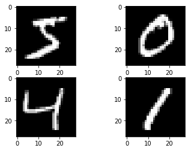

```python
# Plot ad hoc mnist instances
from keras.datasets import mnist
import matplotlib.pyplot as plt
# load (downloaded if needed) the MNIST dataset
(X_train, y_train), (X_test, y_test) = mnist.load_data()
# plot 4 images as gray scale
plt.subplot(221)
plt.imshow(X_train[0], cmap=plt.get_cmap('gray'))
plt.subplot(222)
plt.imshow(X_train[1], cmap=plt.get_cmap('gray'))
plt.subplot(223)
plt.imshow(X_train[2], cmap=plt.get_cmap('gray'))
plt.subplot(224)
plt.imshow(X_train[3], cmap=plt.get_cmap('gray'))
# show the plot
plt.show()
```

#### Loading the required libraries

```python
import numpy
from keras.datasets import mnist
from keras.models import Sequential
from keras.layers import Dense
from keras.layers import Dropout
from keras.utils import np_utils
```

```python
# fix random seed for reproducibility
seed = 7
numpy.random.seed(seed)
```

#### Loading the dataset

```python
# load data
(X_train, y_train), (X_test, y_test) = mnist.load_data()
```

```python
# flatten 28*28 images to a 784 vector for each image
num_pixels = X_train.shape[1] * X_train.shape[2]
X_train = X_train.reshape(X_train.shape[0], num_pixels).astype('float32')
X_test = X_test.reshape(X_test.shape[0], num_pixels).astype('float32')
```

```python
# normalize inputs from 0-255 to 0-1
X_train = X_train / 255
X_test = X_test / 255
```

```python
# one hot encode outputs
y_train = np_utils.to_categorical(y_train)
y_test = np_utils.to_categorical(y_test)
num_classes = y_test.shape[1]
```

#### Building our neural network model

```python
# define baseline model
def baseline_model():
    # create model
    model = Sequential()
    model.add(Dense(num_pixels, input_dim=num_pixels, kernel_initializer='normal', activation='relu'))
    model.add(Dense(num_classes, kernel_initializer='normal', activation='softmax'))
    # Compile model
    model.compile(loss='categorical_crossentropy', optimizer='adam', metrics=['accuracy'])
    return model
```

#### Evaluating our neural network model

```python
# build the model
model = baseline_model()
# Fit the model
model.fit(X_train, y_train, validation_data=(X_test, y_test), epochs=10, batch_size=200, verbose=2)
# Final evaluation of the model
scores = model.evaluate(X_test, y_test, verbose=0)
print("Baseline Error: %.2f%%" % (100-scores[1]*100))
```

```
Train on 60000 samples, validate on 10000 samples
 - 7s - loss: 0.2793 - acc: 0.9208 - val_loss: 0.1419 - val_acc: 0.9574
 - 6s - loss: 0.1118 - acc: 0.9675 - val_loss: 0.0917 - val_acc: 0.9713
 - 6s - loss: 0.0716 - acc: 0.9796 - val_loss: 0.0778 - val_acc: 0.9775
 - 6s - loss: 0.0503 - acc: 0.9855 - val_loss: 0.0742 - val_acc: 0.9771
 - 5s - loss: 0.0374 - acc: 0.9892 - val_loss: 0.0676 - val_acc: 0.9792
 - 5s - loss: 0.0268 - acc: 0.9929 - val_loss: 0.0630 - val_acc: 0.9802
 - 5s - loss: 0.0211 - acc: 0.9947 - val_loss: 0.0617 - val_acc: 0.9808
 - 6s - loss: 0.0140 - acc: 0.9969 - val_loss: 0.0614 - val_acc: 0.9802
 - 6s - loss: 0.0106 - acc: 0.9979 - val_loss: 0.0591 - val_acc: 0.9815
 - 5s - loss: 0.0079 - acc: 0.9986 - val_loss: 0.0595 - val_acc: 0.9813
Baseline Error: 1.87%
```

## Concluding Note-

I hope this gentle introduction will encourage a number of beginners to delve deeper into Machine Learning and implement various models on exciting datasets. The main aim of this article was to provide a succinct analysis of the major ML models being implemented right now and to help learners forge their path in the amazing world of Machine Learning. What I would encourage everyone to do is to look up on the internet for detailed explanations of the mathematical concepts being implemented here and to practice them in a way that they are able to create something new out of it. Also, in place of diving head-first into python programming, I would recommend the readers to go through the code given here and understand the functions and the libraries implemented here firstly and then try to find ways to optimise the performance of the model. This would serve to expedite your learning process and you won't make the same mistakes I did when I was starting out.

```
    Signing off!
    Shashank Shekhar
```

[figure not shown]

### **REFERENCES-**

- Analytics Vidhya
- KDNuggets
- scikit-learn official documentation
- matplotlib official documentation
- 3Blue1Brown videos on youtube on neural networks